# PSL: kNN vs Linear Regression

### Week 1 Example (Fall 2025)

We replicate one of the examples in the ESL book to illustrate the differences between the two simplest prediction methods for binary outcomes: the *Regression method* and the *$k$-Nearest-Neighbors method*.

### Simulation

#### Code for the Simulation

Set the model parameters for the simulation:

```python
p = 2          ## No. of parameters
sigma = 1      ## St. Dev for the Normals (common)
mu1 = [1, 0]   ## Vector of means for the first Normal
mu0 = [0, 1]   ## Vector of means for the second Normal
```

Generate $n$ i.i.d. (independent and identically distributed) samples from each normal to create the *training* data set.

```python
import numpy as np

# convert to arrays
mu1 = np.asarray(mu1, dtype=float)
mu0 = np.asarray(mu0, dtype=float)

# given/assumed:
n = 100          # training sample size per class

rng = np.random.default_rng(0)

# Gaussian noise: 2n x p i.i.d. N(0, sigma^2)
noise = rng.standard_normal((2*n, p)) * sigma

# Stack n copies of mu1 on top of n copies of mu0 (2n x p)
means = np.vstack([
    np.repeat(mu1[None, :], n, axis=0),
    np.repeat(mu0[None, :], n, axis=0)
])

# Training data
traindata = noise + means   # shape (2n, p)

# Labels: first n are 1's, next n are 0's (to match the R code)
Ytrain = np.concatenate([np.ones(n, dtype=int), np.zeros(n, dtype=int)])
```

Generate $N$ *test* samples in a similar way:

```python
N = 10000
rng = np.random.default_rng(1)

# Gaussian noise: 2N x p i.i.d. N(0, sigma^2)
noise_test = rng.standard_normal((2*N, p)) * sigma

# Stack N copies of mu1 on top of N copies of mu0 (2N x p)
means_test = np.vstack([
    np.repeat(mu1[None, :], N, axis=0),
    np.repeat(mu0[None, :], N, axis=0)
])

# Test data
testdata = noise_test + means_test

# Labels: first N are 1's, next N are 0's
Ytest = np.concatenate([np.ones(N, dtype=int), np.zeros(N, dtype=int)])
```

### Visualization of the Simulated Data

We visualize the data we generated -- those in the `traindata` matrix.

#### Plotting using matplotlib

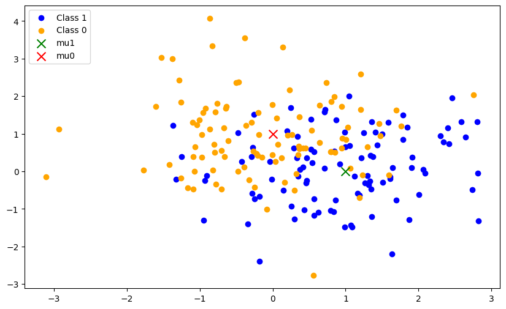

```python
import matplotlib.pyplot as plt

# Create an empty plot (equivalent to type="n" in R)
plt.figure(figsize=(10,6))
plt.scatter([], [], label="")  # just to set up axes
plt.xlabel("")
plt.ylabel("")

# Plot Class 1 points (first n samples) in blue
plt.scatter(traindata[:n, 0], traindata[:n, 1],
            c="blue", marker="o", label="Class 1")

# Plot Class 0 points (next n samples) in orange
plt.scatter(traindata[n:2*n, 0], traindata[n:2*n, 1],
            c="orange", marker="o", label="Class 0")

# Add centers: class 1 (green), class 0 (red)
plt.scatter(mu1[0], mu1[1], c="green", marker="x", s=100, label="mu1")
plt.scatter(mu0[0], mu0[1], c="red", marker="x", s=100, label="mu0")

# Legend (just for the two classes, like R’s code)
plt.legend(loc="upper left")

plt.show()
```

### $k$ Nearest-Neighbors Method

To apply the $k$-NN method, we need to choose $k$. In the example below, we use the neighborhood sizes suggested from the textbook (ESL). We also apply and plot the results for $k=1$ and $k=15$.

```python
import numpy as np
from sklearn.neighbors import KNeighborsClassifier

neighbor_size = [151, 101, 69, 45, 31, 21, 11, 7, 5, 3, 1]
m = len(neighbor_size)

train_err_knn = np.zeros(m)
test_err_knn = np.zeros(m)

for j, k in enumerate(neighbor_size):
    # Fit kNN on training data
    knn = KNeighborsClassifier(n_neighbors=k)
    knn.fit(traindata, Ytrain)

    # Predictions on training data
    Ytrain_pred = knn.predict(traindata)
    train_err_knn[j] = np.mean(Ytrain != Ytrain_pred)

    # Predictions on testing data
    Ytest_pred = knn.predict(testdata)
    test_err_knn[j] = np.mean(Ytest != Ytest_pred)

# Put results together (like cbind in R)
results = np.column_stack((train_err_knn, test_err_knn))

print("Train Error | Test Error")
print(results)
```

```
Train Error | Test Error
[[0.235   0.24   ]
 [0.235   0.24415]
 [0.245   0.2444 ]
 [0.245   0.24595]
 [0.22    0.24575]
 [0.225   0.24625]
 [0.24    0.25115]
 [0.215   0.25835]
 [0.23    0.2587 ]
 [0.19    0.2725 ]
 [0.      0.32185]]
```

#### 5-Fold Cross-Validation for Choosing optimal $k$

A systematic way to determine the *optimal* value for the neighborhood size, $k$, in a range of values is the so-called 5-fold Cross-Validation (CV) method. Essentially, the method selects the $k$ value that minimizes the CV error. In a nutshell, the 5-fold CV error for each $k$ is a *sum of 5 prediction errors*, one corresponding to each fold.

In the code below, we have an outside loop from 1 to 5 (the folds), and an inside loop from 1 to $m$ (all possible values for $k$). Inside the loop, we use 80% (i.e., four folds) of the data as training and predict on the 20% (i.e., one fold) holdout set.

```python
# assumes traindata (shape (2*n, p)), Ytrain (shape (2*n,)),
# testdata (shape (2*N, p)), Ytest (shape (2*N,)) already exist
# and neighbor_size is defined as in your code
# e.g. neighbor_size = [151, 101, 69, 45, 31, 21, 11, 7, 5, 3, 1]

n_total = traindata.shape[0]          # should be 2*n
assert n_total % 5 == 0, "Code expects folds of equal size."
fold_size = n_total // 5

# Make a random permutation of indices 0..(2n-1) (R used 1..2n then 1-based slicing)
rng = np.random.default_rng(0)        # set seed if you want reproducibility
idx = rng.permutation(n_total)

# Fold boundaries like R's: c(0, 40, 80, 120, 160, 200) when 2n=200
fold_bounds = np.arange(0, n_total + 1, fold_size)

m = len(neighbor_size)
cv_error_counts = np.zeros(m, dtype=int)  # accumulate misclassification counts over all folds

# 5-fold CV
for i in range(5):
    val_idx = idx[fold_bounds[i]:fold_bounds[i+1]]
    train_idx = np.setdiff1d(idx, val_idx, assume_unique=True)

    X_tr, y_tr = traindata[train_idx], Ytrain[train_idx]
    X_val, y_val = traindata[val_idx], Ytrain[val_idx]

    for j, k in enumerate(neighbor_size):
        knn = KNeighborsClassifier(n_neighbors=k)
        knn.fit(X_tr, y_tr)
        y_val_pred = knn.predict(X_val)
        cv_error_counts[j] += np.sum(y_val_pred != y_val)

# Choose k with the smallest total CV misclassification count
k_optimal = neighbor_size[int(np.argmin(cv_error_counts))]
cv_error_rate = cv_error_counts / n_total  # optional, to view as rates

# print("CV misclassification counts per k:", cv_error_counts)
# print("CV error rates per k:", cv_error_rate)
print("Optimal k (5-fold CV):", k_optimal)

# Train/test errors using the CV-selected k
knn_cv = KNeighborsClassifier(n_neighbors=k_optimal)
knn_cv.fit(traindata, Ytrain)

Ytrain_pred = knn_cv.predict(traindata)
train_err_knn_CV = np.mean(Ytrain_pred != Ytrain)

Ytest_pred = knn_cv.predict(testdata)
test_err_knn_CV = np.mean(Ytest_pred != Ytest)

print("Train error (CV-chosen k):", train_err_knn_CV)
print("Test error  (CV-chosen k):", test_err_knn_CV)
```

```
Optimal k (5-fold CV): 101
Train error (CV-chosen k): 0.235
Test error  (CV-chosen k): 0.24415
```

### Least Squares Method

We run a regression of `Ytrain` vs. the `traindata`, and we classify the results as follows: \[\hat{Y} = \begin{cases} & 1, \text{ if } fitted(Y) > 0.5\\ & 0, \text{ if } fitted(Y) \leq 0.5 \end{cases} \]

```python
from sklearn.linear_model import LinearRegression
from sklearn.metrics import confusion_matrix

# Ytrain is {0,1}, already numeric
# traindata is (2*n, p), testdata is (2*N, p)

# Fit linear regression model
reg = LinearRegression()
reg.fit(traindata, Ytrain)

# Training predictions: fitted values > 0.5 → class 1, else class 0
Ytrain_pred_LS = (reg.predict(traindata) > 0.5).astype(int)

# Testing predictions
Ytest_pred_cont = reg.predict(testdata)   # continuous values
Ytest_pred_LS = (Ytest_pred_cont > 0.5).astype(int)

# Cross-tabs (confusion matrices)
train_cm = confusion_matrix(Ytrain, Ytrain_pred_LS, labels=[0,1])
test_cm  = confusion_matrix(Ytest,  Ytest_pred_LS,  labels=[0,1])

train_err_LS = np.mean(Ytrain != Ytrain_pred_LS)
test_err_LS  = np.mean(Ytest  != Ytest_pred_LS)

print("Train confusion matrix:\n", train_cm)
print("Train error (LS):", train_err_LS)

print("\nTest confusion matrix:\n", test_cm)
print("Test error (LS):", test_err_LS)

# Inspect coefficients (like R’s RegModel$coef)
# print("\nIntercept:", reg.intercept_)
# print("Coefficients:", reg.coef_)
```

```
Train confusion matrix:
 [[75 25]
 [20 80]]
Train error (LS): 0.225

Test confusion matrix:
 [[7307 2693]
 [2154 7846]]
Test error (LS): 0.24235
```

### Illustration of the Results

First, we illustrate the classification achieved by each method.

#### kNN Classification for two k's: k = 15 and k = 1

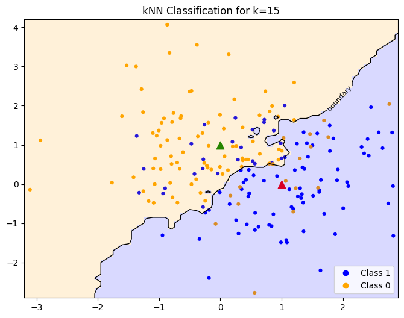

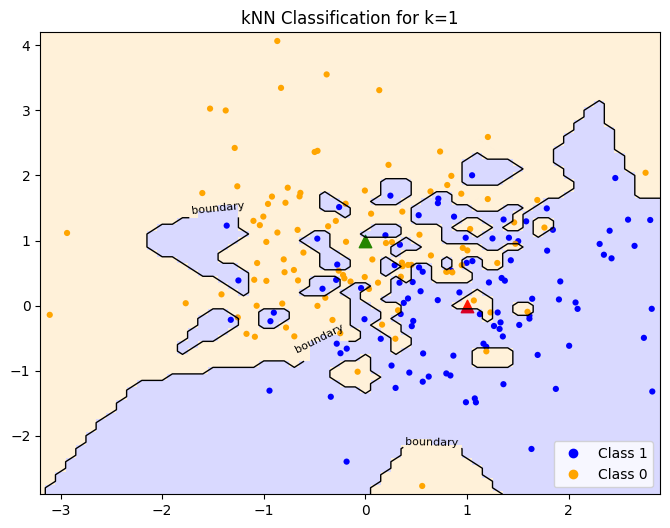

```python
# --- Define plot ranges like your R code ---
x_min = np.round(traindata[:, 0].min(), 1) - 0.1
x_max = np.round(traindata[:, 0].max(), 1) + 0.1
y_min = np.round(traindata[:, 1].min(), 1) - 0.1
y_max = np.round(traindata[:, 1].max(), 1) + 0.1

x_range = np.arange(x_min, x_max + 1e-9, 0.1)
y_range = np.arange(y_min, y_max + 1e-9, 0.1)

XX, YY = np.meshgrid(x_range, y_range)
grid_points = np.c_[XX.ravel(), YY.ravel()]  # same as expand.grid

# Base scatter (like grid.plot in ggplot)
def base_scatter(ax):
    # Ytrain: 1 -> blue, 0 -> orange to match your ggplot colors
    colors = np.where(Ytrain == 1, "blue", "orange")
    ax.scatter(traindata[:, 0], traindata[:, 1], c=colors, s=20, edgecolor="none")
    # Centers
    ax.scatter(mu1[0], mu1[1], c="red", marker="^", s=80)    # class 1 center
    ax.scatter(mu0[0], mu0[1], c="green", marker="^", s=80)  # class 0 center
    ax.set_xlabel("")
    ax.set_ylabel("")
    ax.set_xlim(x_min, x_max)
    ax.set_ylim(y_min, y_max)
    ax.legend(handles=[
        plt.Line2D([], [], marker="o", linestyle="", color="blue", label="Class 1"),
        plt.Line2D([], [], marker="o", linestyle="", color="orange", label="Class 0")
    ], loc="lower right")

def plot_knn_decision(k, title):
    # Fit kNN on training set
    knn = KNeighborsClassifier(n_neighbors=k)
    knn.fit(traindata, Ytrain)

    # Predict on grid
    # For a shaded background like ggplot, we can use class predictions on the grid
    grid_pred = knn.predict(grid_points).reshape(XX.shape)

    # For a crisp decision boundary, use class-1 probability and contour at 0.5
    if hasattr(knn, "predict_proba"):
        grid_proba1 = knn.predict_proba(grid_points)[:, 1].reshape(XX.shape)
    else:
        # Fallback (rare for KNN): approximate boundary by cast to float of predictions
        grid_proba1 = grid_pred.astype(float)

    fig, ax = plt.subplots(figsize=(8, 6))
    base_scatter(ax)

    # Shaded regions: match colors (0 -> orange, 1 -> blue)
    # We'll map 0/1 to 0/1 and use a ListedColormap with the same two colors
    from matplotlib.colors import ListedColormap
    cmap_bg = ListedColormap(["orange", "blue"])

    ax.pcolormesh(XX, YY, grid_pred, shading="auto", alpha=0.15, cmap=cmap_bg)

    # Decision contour at prob=0.5 (1 bin/level in ggplot)
    CS = ax.contour(XX, YY, grid_proba1, levels=[0.5], colors="black", linewidths=1.0)
    ax.clabel(CS, fmt={0.5: "boundary"}, inline=True, fontsize=8)

    ax.set_title(f"kNN Classification for k={k}")
    plt.show()

# Plots equivalent to your ggplot figures:
plot_knn_decision(k=15, title="kNN Classification for k=15")
plot_knn_decision(k=1,  title="kNN Classification for k=1")
```

#### Regression Classification

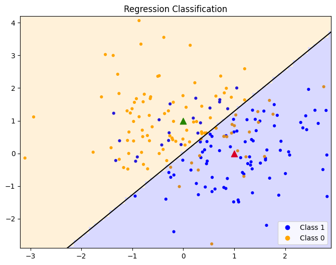

```python
from matplotlib.colors import ListedColormap

# --- Fit linear regression: Y ~ X1 + X2 (with intercept) ---
reg = LinearRegression()
reg.fit(traindata, Ytrain)

beta0 = reg.intercept_          # corresponds to beta.hat[1] in R (1-based)
beta1, beta2 = reg.coef_        # corresponds to beta.hat[2], beta.hat[3]

# --- Predict on grid (like Reg.yhat = [1, X] %*% beta.hat) ---
grid_yhat = reg.predict(grid_points)              # continuous predictions
grid_pred = (grid_yhat > 0.5).astype(int)         # class labels as 0/1
grid_pred_img = grid_pred.reshape(XX.shape)

# --- Decision boundary (beta0 + beta1*x + beta2*y = 0.5) ---
# Solve for y: y = -(beta1/beta2) * x + (0.5 - beta0)/beta2
# (only draw if beta2 != 0)
fig, ax = plt.subplots(figsize=(8, 6))
base_scatter(ax)

# Shaded class regions to mirror the R ggplot points background
cmap_bg = ListedColormap(["orange", "blue"])
ax.pcolormesh(XX, YY, grid_pred_img, shading="auto", alpha=0.15, cmap=cmap_bg)

# Decision boundary line
if np.abs(beta2) > 1e-12:
    x_line = np.array([ax.get_xlim()[0], ax.get_xlim()[1]])
    slope = -beta1 / beta2
    intercept = (0.5 - beta0) / beta2
    y_line = slope * x_line + intercept
    ax.plot(x_line, y_line, color="black", linewidth=1.5)
else:
    # Vertical boundary when beta2 ≈ 0: beta0 + beta1*x = 0.5 → x = (0.5 - beta0)/beta1
    if np.abs(beta1) > 1e-12:
        x_vert = (0.5 - beta0) / beta1
        ax.axvline(x_vert, color="black", linewidth=1.5)

ax.set_title("Regression Classification")
plt.show()
```

#### Plot the Performance and Compare the two Methods

Test errors are in `magenta` and training errors are in `blue`. The upper $x$-coordinate indicates the $k$ values, and the lower $x$-coordinate indicates the degrees-of-freedom of the $k$NN procedures so that the labels are reciprocally related to $k$.

The training and test errors for linear regression are plotted at $df = 3$ (corresponding to $k = (2n)/3$), since the linear model has 3 parameters, i.e., 3 dfs.

The training and test errors for KNN with $k$ chosen by CV are plotted at the chose $k$ values.

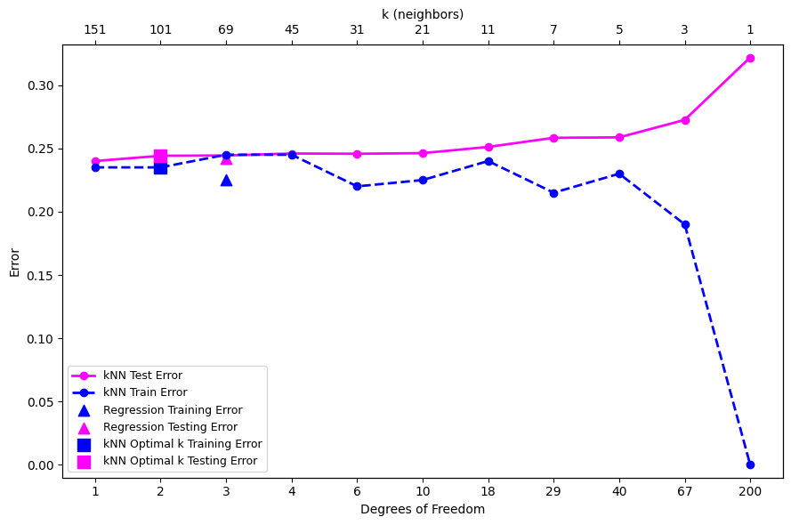

```python
# Degrees of freedom: round((2*n)/k)
df = np.round((2*n) / np.array(neighbor_size)).astype(int)

x = np.arange(1, m+1)

y_min = min(
    np.min(test_err_LS),
    np.min(train_err_LS),
    np.min(test_err_knn),
    np.min(train_err_knn),
)
y_max = max(
    np.max(test_err_LS),
    np.max(train_err_LS),
    np.max(test_err_knn),
    np.max(train_err_knn),
)

fig, ax = plt.subplots(figsize=(9, 6))

# Empty base (like type="n")
ax.set_xlim(0.5, m + 0.5)
ax.set_ylim(y_min - 0.01, y_max + 0.01)
ax.set_xlabel("Degrees of Freedom")
ax.set_ylabel("Error")

# Bottom axis ticks: degrees of freedom
ax.set_xticks(x)
ax.set_xticklabels(df)

# Top axis: k (neighbor_size)
ax_top = ax.twiny()
ax_top.set_xlim(ax.get_xlim())
ax_top.set_xticks(x)
ax_top.set_xticklabels(neighbor_size)
ax_top.set_xlabel("k (neighbors)")

# kNN curves
ax.plot(x, test_err_knn, color="magenta", linewidth=2, linestyle="-", marker="o", label="kNN Test Error")
ax.plot(x, train_err_knn, color="blue",    linewidth=2, linestyle="--", marker="o", label="kNN Train Error")

# Linear regression errors at x=3 (to match your R code)
ax.scatter([3], [train_err_LS], color="blue",    marker="^", s=80, label="Regression Training Error")
ax.scatter([3], [test_err_LS],  color="magenta", marker="^", s=80, label="Regression Testing Error")

# CV-chosen k marker at its position
pos_opt = x[np.array(neighbor_size) == k_optimal][0]  # 1-based position
ax.scatter([pos_opt], [train_err_knn_CV], color="blue",    marker="s", s=90, label="kNN Optimal k Training Error")
ax.scatter([pos_opt], [test_err_knn_CV],  color="magenta", marker="s", s=90, label="kNN Optimal k Testing Error")

# Legend (grouped, similar to R)
ax.legend(loc="lower left", fontsize=9)

plt.tight_layout()
plt.show()
```